# Analise de pernas de ônibus

Luiz Alberto Fonseca

September 5, 2017

```r
library(readr)
library(ggplot2)
library(tidyverse)
library(resample)
```

Primeiramente importaremos os dados:

```r
dados.bulma <- read_csv("dadostratados.csv")
```

Vamos ver como se comportam as durações durante o dia:

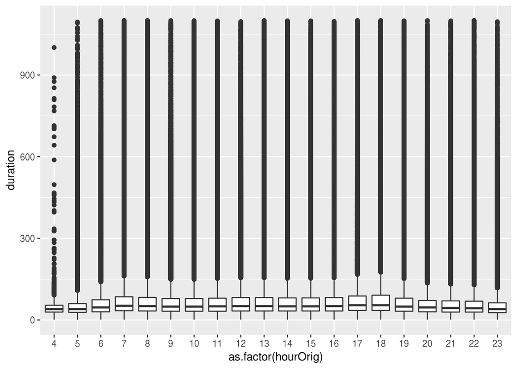

```r
dados.bulma %>%
  ggplot(aes(x = as.factor(hourOrig), y = duration)) +
  geom_boxplot()
```

Vemos que apenas os horários abaixo das 7 horas e acima das 18 horas parecem ser menores que os demais.

Vamos comparar a hora com as demais horas do dia, ou seja, para cada dia, como se comporta aquela hora em comparação com as demais:

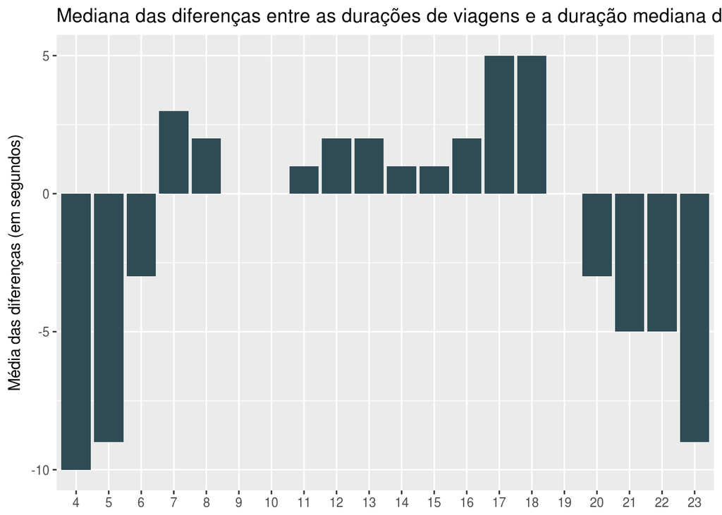

```r
summarised.dates <- dados.bulma %>% group_by(date) %>%
  summarise(meanDuration = mean(duration),
            medianDuration = median(duration))

temp1 <- dados.bulma %>% select(date, hourOrig, hourDest, duration)
temp1 <- left_join(temp1, summarised.dates, by = "date")
summarised.dates <- NULL

# Diferença entre cada duração e a duração mediana do dia
temp1 <- temp1 %>% mutate(
  diffFromMedian = duration - medianDuration
)

# Mediana das diferenças por hora
temp2 <- temp1 %>% group_by(hourOrig) %>%
  summarise(
   medianOfDiffs = median(diffFromMedian)
)
temp1 <- NULL

# plot
ggplot(temp2, aes(as.factor(hourOrig), medianOfDiffs)) +
  geom_bar(stat = "identity", fill = "#2f4c56", legend = FALSE) +
  scale_y_continuous("Média das diferenças (em segundos)") +
  theme(axis.title.x = element_blank()) +
  labs(title = "Mediana das diferenças entre as durações de viagens e a duração mediana do dia")
```

```r
temp2 <- NULL
```

Podemos perceber que parece existir três horários de pico locais, das 7 às 8 horas, 12 às 13 e das 16 às 18 horas.

```r
# Vejamos se realmente existe uma diferença significativa:

# set.seed(66)
#
# boot.dados.bulma.by.hour <- dados.bulma %>%
#   group_by(hourOrig) %>%
#   summarise(
#     y.025 = CI.bca(bootstrap(data = duration, statistic = mean, seed = 66, R = 100), probs = c(.025, .975))[1],
#     y.975 = CI.bca(bootstrap(data = duration, statistic = mean, seed = 66, R = 100), probs = c(.025, .975))[2]
#   )
#
# boot.dados.bulma.by.hour %>%
#   ggplot(aes(x = hourOrig, ymin = y.025, ymax = y.975)) +
#   geom_errorbar()
# boot.dados.bulma.by.hour <- NULL

# Podemos ver que os horários de pico determinados anteriormente, entre 7 e 8 horas tem viagens com duração maior que as anteriores e maiores que as viagens após as 19 horas, mas não se pode concluir nada sobre as demais. Definitivamente 18 horas é um horário de pico, visto que é maior que as demais.
```

## Dia da semana

```r
# Vejamos agora as durações para cada dia da semana:

# boot.dados.bulma.by.weekday <- dados.bulma %>%
#   group_by(weekDay) %>%
#   summarise(
#     y.025 = CI.bca(bootstrap(data = duration, statistic = mean, seed = 66, R = 100), probs = c(.025, .975))[1],
#     y.975 = CI.bca(bootstrap(data = duration, statistic = mean, seed = 66, R = 100), probs = c(.025, .975))[2]
#   )
#
# boot.dados.bulma.by.weekday %>%
#   mutate(weekDay = factor(weekDay, levels = c("Sun", "Mon", "Tue", "Wed", "Thu", "Fri", "Sat"))) %>%
#   arrange(weekDay) %>%
#   ggplot(aes(x = weekDay, ymin = y.025, ymax = y.975)) +
#   geom_errorbar()
#
# boot.dados.bulma.by.weekday <- NULL

# Podemos perceber que o dia em que os ônibus mais demoram é a segunda-feira, visto que é o único que existe uma diferença significativa de duração em relação aos demais. A quinta-feira também tem uma duração mais elevada quando comparada aos demais, exceto à segunda-feira e quarta-feira.
```

Vejamos agora a diferença da duração da viagem em relação à duração mediana semanal.

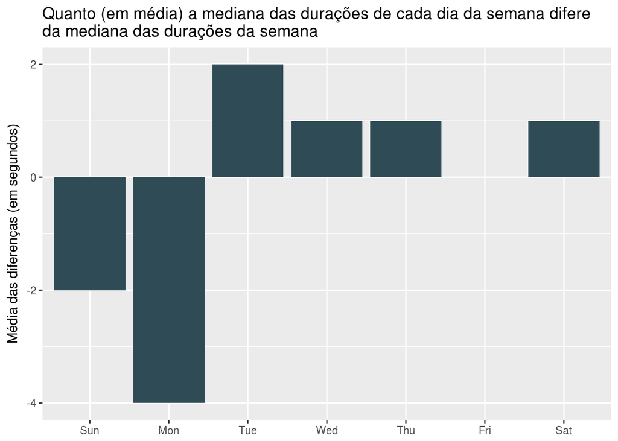

```r
summarised.weeks <- dados.bulma %>% group_by(weekOfYear) %>%
  summarise(medianWeek = median(duration))

temp3 <- dados.bulma %>% select(weekOfYear, weekDay, duration)
temp3 <- left_join(temp3, summarised.weeks, by = "weekOfYear")
summarised.weeks <- NULL

# Diferença entre cada duração e a duração mediana da semana
temp3 <- temp3 %>% mutate(
  diffFromMedian = duration - medianWeek
)

# Mediana das diferenças por dia da semana
temp4 <- temp3 %>% group_by(weekDay) %>%
  summarise(
   medianOfDiffs = median(diffFromMedian)
)
temp3 <- NULL

temp4 %>%
  mutate(weekDay = factor(weekDay, levels = c("Sun", "Mon", "Tue", "Wed", "Thu", "Fri", "Sat"))) %>%
  arrange(weekDay) %>%
  ggplot(aes(as.factor(weekDay), medianOfDiffs)) +
    geom_bar(stat = "identity", fill = "#2f4c56", legend = FALSE) +
    scale_y_continuous("Média das diferenças (em segundos)") +
    theme(axis.title.x = element_blank()) +
    labs(title = "Quanto (em média) a mediana das durações de cada dia da semana difere \nda mediana das durações da semana")
```

```r
temp4 <- NULL
```

Podemos ver que, a terça, quarta e quinta tem uma duração maior que as durações dos demais dias, com exceção do sábado.

## Área da cidade

```r
library(ggmap)

m <- get_map("Curitiba",zoom=11,maptype="toner",source="stamen")

g <- ggmap(m)
m <- NULL
# g +
#   stat_density2d(aes(x = shapeLonOrig, y = shapeLatOrig, fill=duration, colour = duration), data=dados.bulma,geom="polygon", alpha=0.2, contour = T) +
#   scale_fill_gradient(low = "yellow", high = "red")

# Vemos que o centro da cidade tem maior quantidades de viagens.
```

Vejamos as viagens e suas durações individualmente

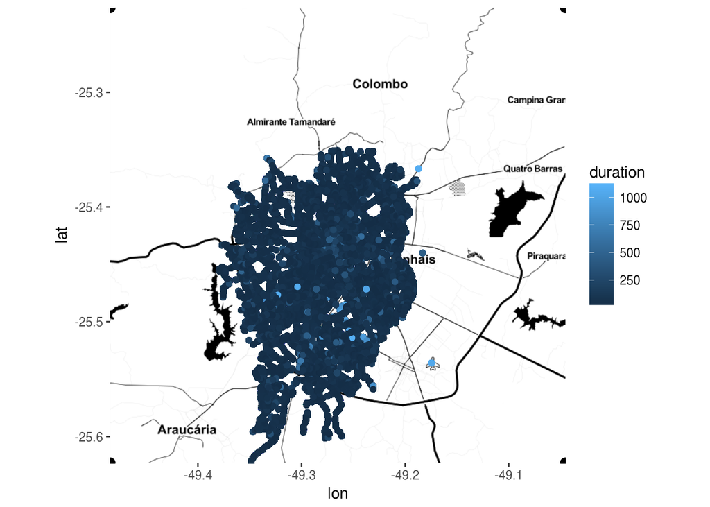

```r
g +
  geom_point(aes(x = shapeLonOrig, y = shapeLatOrig, color = duration), data = dados.bulma) +
  geom_point(size=3,alpha=1)
```

Não é possível afirmar com certeza quais regiões da cidade tem maior duração.

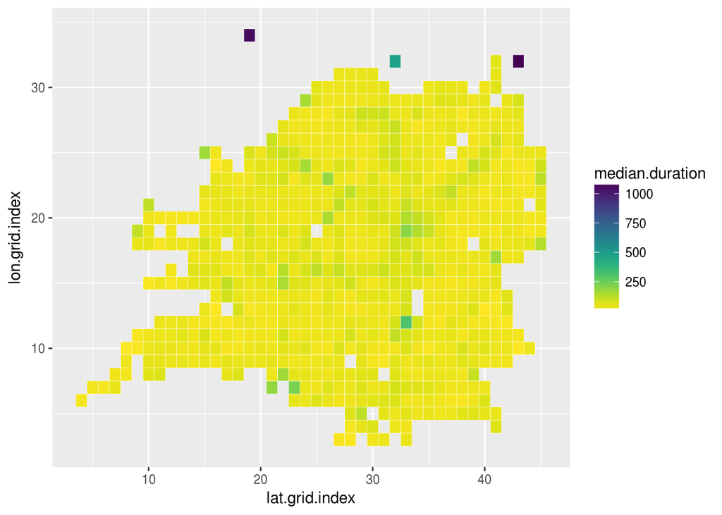

```r
lat.min <- -25.67
lat.max <- -25.32
lon.min <- -49.40
lon.max <- -49.07

lat.step <- (lat.max - lat.min) / 50
lon.step <- (lon.max - lon.min) / 50

dados.bulma.grid <- dados.bulma %>%
  mutate(
    lat.grid.index = floor((shapeLatOrig - lat.min) / lat.step),
    lon.grid.index = floor((shapeLonOrig - lon.min) / lon.step)
  )

dados.bulma.grid %>%
  group_by(lat.grid.index, lon.grid.index) %>%
  summarise(median.duration = median(duration)) %>%
  ggplot(aes(lat.grid.index, lon.grid.index)) +
    geom_tile(aes(fill = median.duration), colour = "white") +
    viridis::scale_fill_viridis(direction = -1)
```

Vemos que existem locais em que as viagens estão com duração mais alta, mas talvez seja influenciado por algum outlier.

Logo, vamos atenuar os valores maiores.

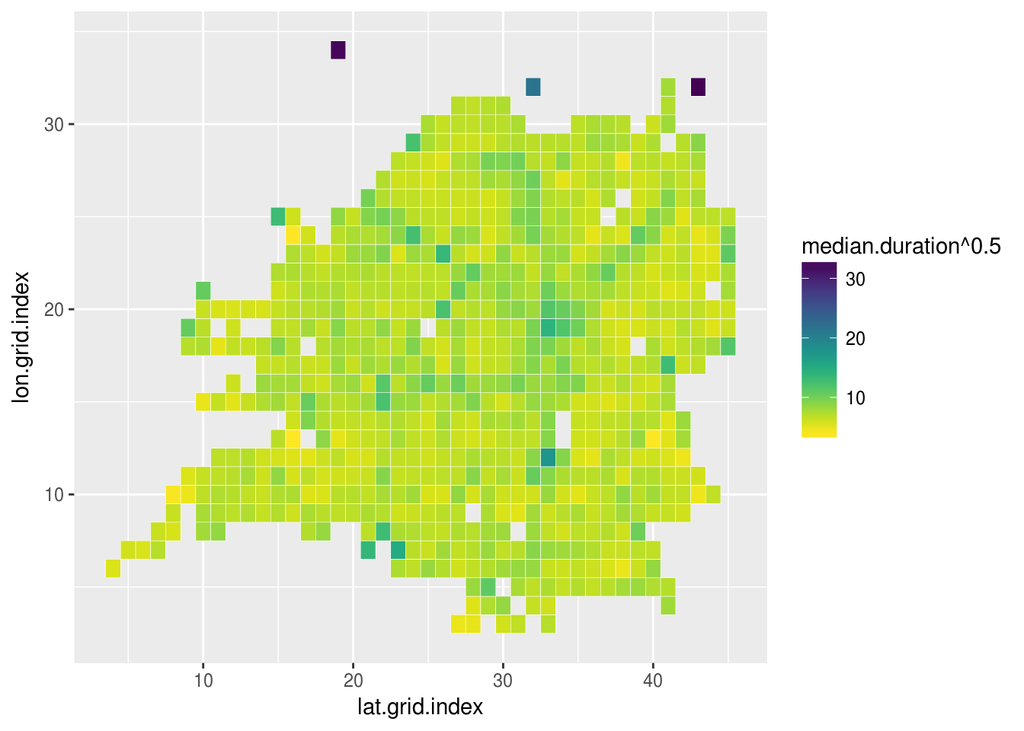

```r
dados.bulma.grid %>%
  group_by(lat.grid.index, lon.grid.index) %>%
  summarise(median.duration = median(duration)) %>%
  ggplot(aes(lat.grid.index, lon.grid.index)) +
    geom_tile(aes(fill = median.duration**.5), colour = "white") +
    viridis::scale_fill_viridis(direction = -1)
```

Parece existir uma maior concentração de durações altas em corredores da cidade.

Vejamos se isso se confirma quando colocamos em um mapa:

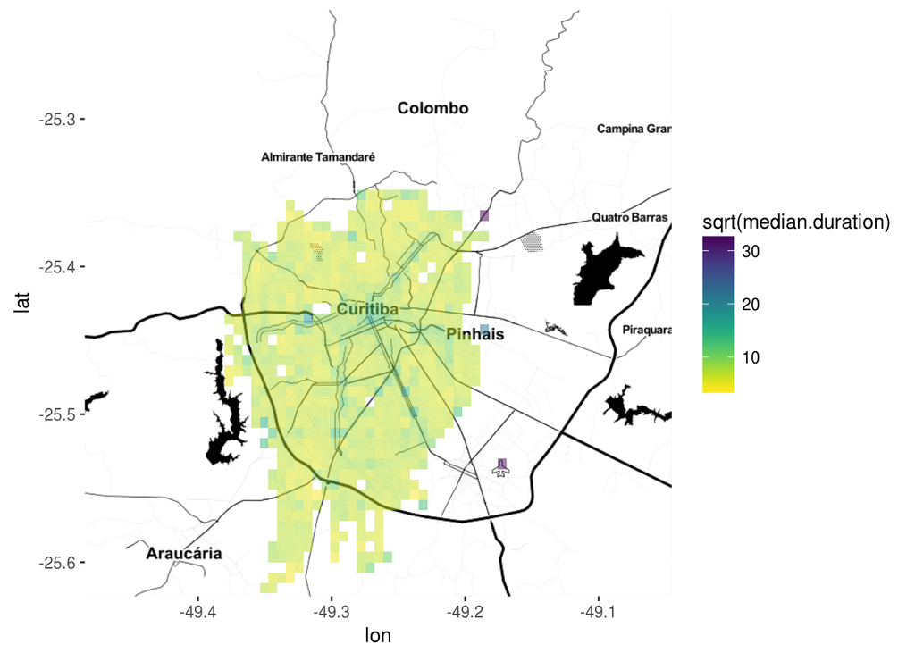

```r
dados.bulma.grid <- dados.bulma.grid %>%
  mutate(
    plotting.lat = lat.min + (lat.grid.index * lat.step + (lat.grid.index + 1) * lat.step) / 2,
    plotting.lon = lon.min + (lon.grid.index * lon.step + (lon.grid.index + 1) * lon.step) / 2
  )

summarised.grid <- dados.bulma.grid %>%
  group_by(plotting.lat, plotting.lon) %>%
  summarise(
    median.duration = median(duration)
  )

g +
  geom_tile(aes(x = plotting.lon, y = plotting.lat, fill = sqrt(median.duration)), data = summarised.grid, alpha = 0.5) +
  viridis::scale_fill_viridis(direction = -1)
```

```r
summarised.grid <- NULL
```

Podemos ver que realmente existem trechos da cidade que tem a duração maior.

Vejamos o quanto que esses trechos se diferenciam da mediana durante:

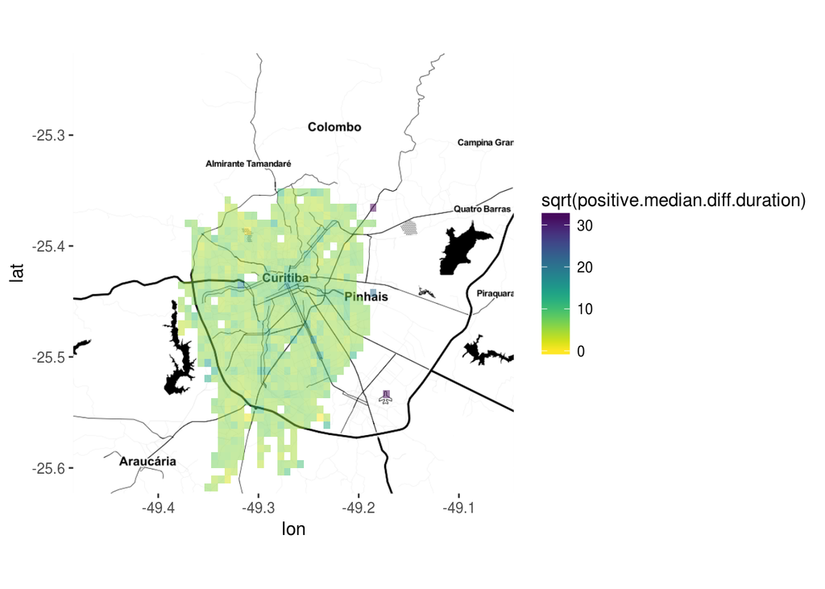

```r
hour.median.duration <- dados.bulma %>%
  group_by(hourOrig) %>%
  summarise(
    median.duration = median(duration)
  )
dados.bulma <- NULL

joined.grid <- left_join(dados.bulma.grid, hour.median.duration, by = "hourOrig") %>%
  mutate(diff.duration = duration - median.duration)
hour.median.duration <- NULL
dados.bulma.grid <- NULL

hourly.summarised.joined.grid <- joined.grid %>%
  group_by(plotting.lat, plotting.lon) %>%
  summarise(
    median.diff.duration = median(diff.duration)
  )
joined.grid <- NULL

min.median.diff.duration <- min(hourly.summarised.joined.grid$median.diff.duration)

hourly.summarised.joined.grid <- hourly.summarised.joined.grid %>%
  mutate(
    positive.median.diff.duration = median.diff.duration + abs(min.median.diff.duration)
  )

g +
  geom_tile(aes(x = plotting.lon, y = plotting.lat, fill = sqrt(positive.median.diff.duration)), data = hourly.summarised.joined.grid, alpha = 0.5) +
  viridis::scale_fill_viridis(direction = -1)
```

Podemos verificar que os mesmos corredores estão presentes ao plotar a diferença do horário para mediana de cada hora.